# Titanic Model Approach

Winston Saunders

December 31, 2014

### Introduction

This is a model for the kaggle Titanic dataset. The idea is to make a predictive model of survivor. Judging from leaderboards, I need to get to predictive accuracy of ~ 80%. Let’s see how we do.

To get the data use the following function. The data are stored in my GitHub.

```r
        readData <- function(path.name, file.name, column.types, missing.types) {
                myData<-getURL(  paste0(path.name, file.name) )
                read.csv(textConnection(myData),
                colClasses=column.types,
                na.strings=missing.types )

}
```

The variables for the function are defined as below. The train.column.types simplifies the data cleaning for the analysis.

```r
        Titanic.path <- "https://raw.githubusercontent.com/ww44ss/Titanic/master/"
        train.data.file <- "train.csv"
        test.data.file <- "test.csv"
        missing.types <- c("NA", "")
        train.column.types <- c('integer',   # PassengerId
                                'factor',    # Survived
                                'factor',    # Pclass
                                'character', # Name
                                'factor',    # Sex
                                'numeric',   # Age
                                'integer',   # SibSp
                                'integer',   # Parch
                                'character', # Ticket
                                'numeric',   # Fare
                                'character', # Cabin
                                'factor'     # Embarked
        )

        test.column.types <- train.column.types[-2]     # # no Survived column in test.csv
```

Now we can get the data quickly

```r
        training <- readData(Titanic.path, train.data.file, train.column.types, missing.types)
        testing <-  readData(Titanic.path, test.data.file, test.column.types, missing.types)

        trainingRaw<-training
        testingRaw<-testing
```

## Model One

Let’s look at the data using the Amelia Package

[output not shown]

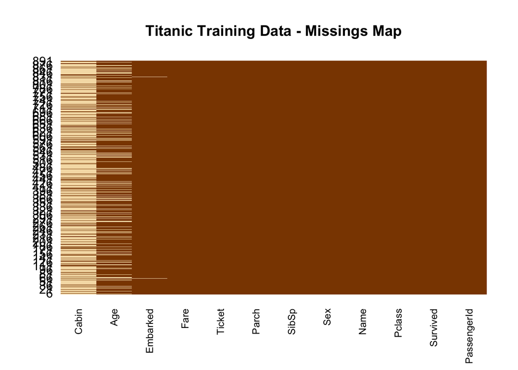

We can explore the data by looking at quick snapshot

[output not shown]

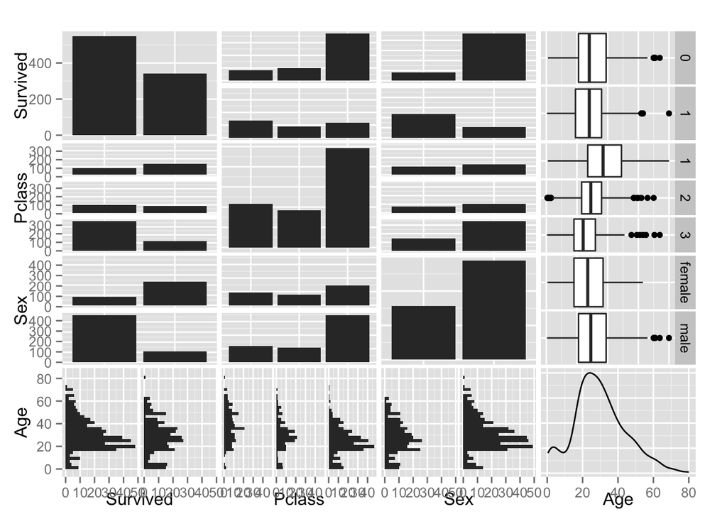

```r
library(GGally)

ggpairs(training[c(2, 3, 5, 6)])
```

Since there are many NA’s in the age data let’s try replacing those with the mean ages for male or females.

```r
training$VeryYoung <- 0
training$VeryYoung[training$Age<10.1]<-1
```

```r
training[1:6,c("Survived", "Age", "Sex", "Pclass", "VeryYoung")]
```

```
##   Survived Age    Sex Pclass VeryYoung
## 1        0  22   male      3         0
## 2        1  38 female      1         0
## 3        1  26 female      3         0
## 4        1  35 female      1         0
## 5        0  35   male      3         0
## 6        0  29   male      3         0
```

Here is the confusion table

```r
conf$table
```

```
##           Reference
## Prediction   0   1
##          0 136   1
##          1  41  44
```

The accuracy is 81.1%.

## Model One Point Five

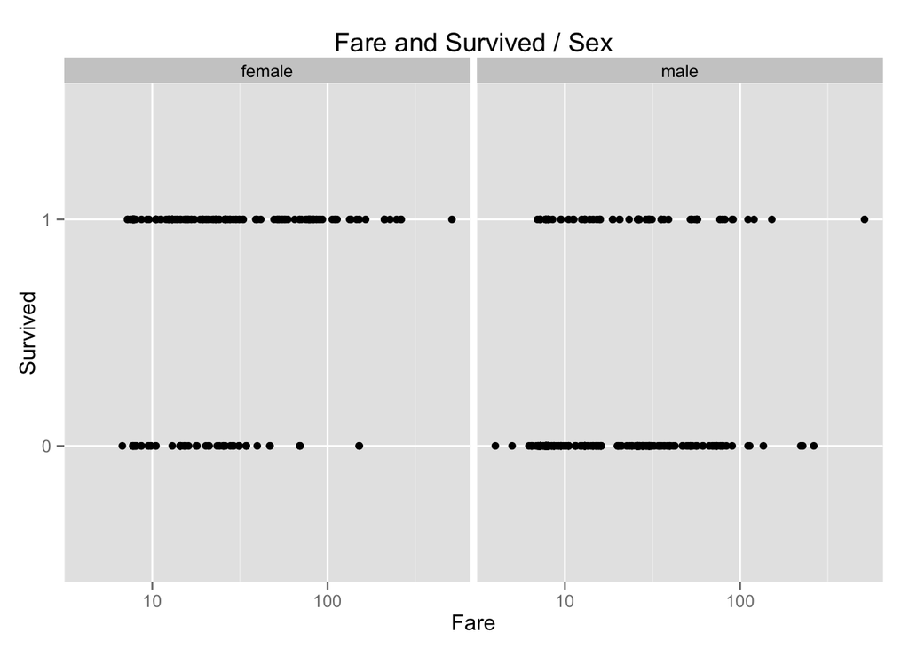

```r
        agemodel<-glm(Age~Pclass+Sex, data=trainfull)
```

```r
        train1$logFare<-log10(train1$Fare)
```

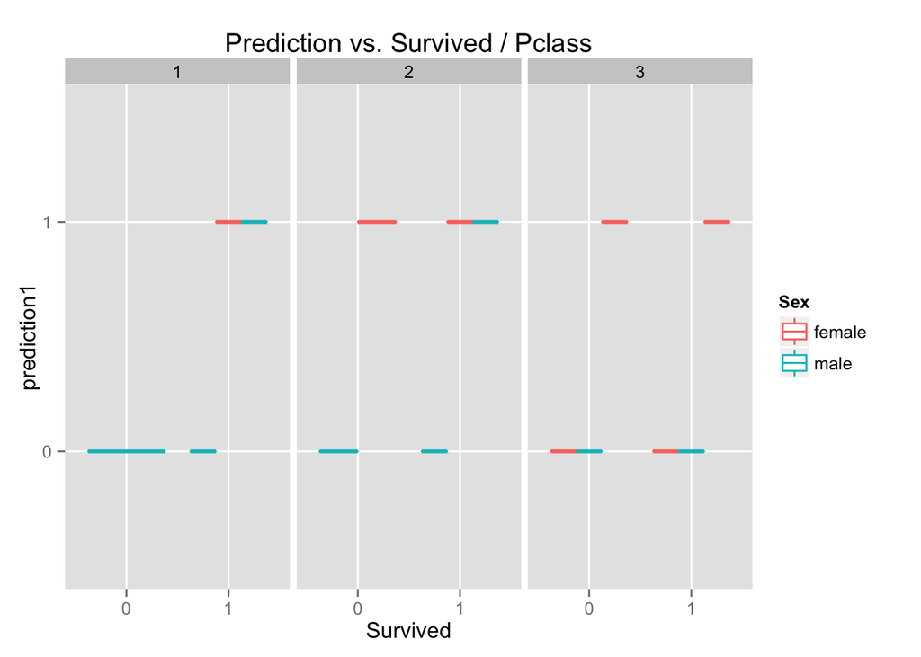

```r
        ## Write output file
```

Resulting in the following confusion matrix

```
##           Reference
## Prediction   0   1
##          0 124  13
##          1  19  66
```

The accuracy is 85.59 versus earlier 81.08%.